# Importing and Graphing Network Data

Dr. Tracy Sweet

## Importing from a Previously Saved R Workspace

We’ll import some network data.

```r
load("WorkshopData.Rdata")
```

# Plotting Network Data in R

Now that we have our data into R, the easiest way to plot our data in R is to use the igraph package. We also have to create igraph objects.

## Making an Igraph Object

```r
library(igraph)
teachergraph=graph_from_adjacency_matrix(as.matrix(Ela9Network), mode="directed")
authorgraph=graph_from_adjacency_matrix(as.matrix(authornet), mode="undirected")
```

## Using the Igraph Default Plot

Sometimes the default ploting function makes perfectly adequate plots and other times, the plots are terrible. You be the judge.

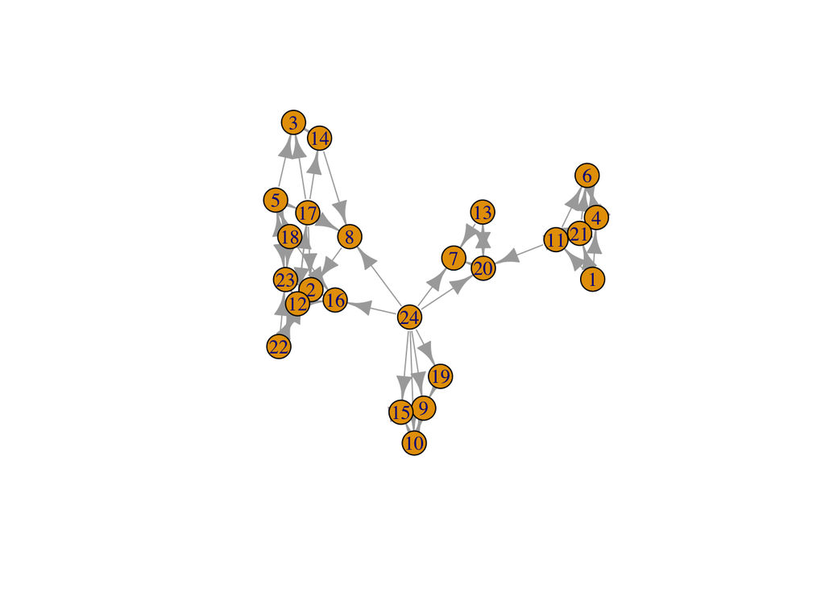

```r
plot(teachergraph)
```

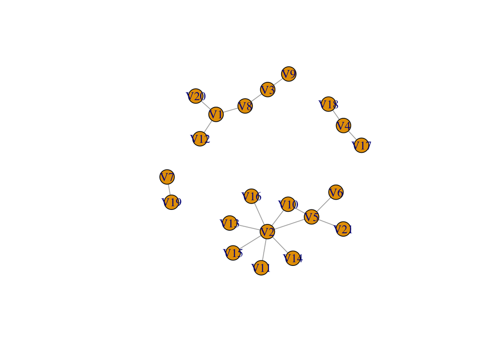

```r
plot(authorgraph)
```

## Let’s redo the teacher plot with some changes

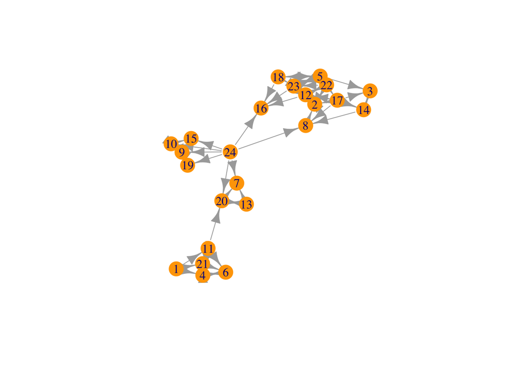

```r
plot(teachergraph, vertex.size=15, vertex.color="orange", vertex.frame.color="NA", edge.width=1, vextex.label=1:13)
```

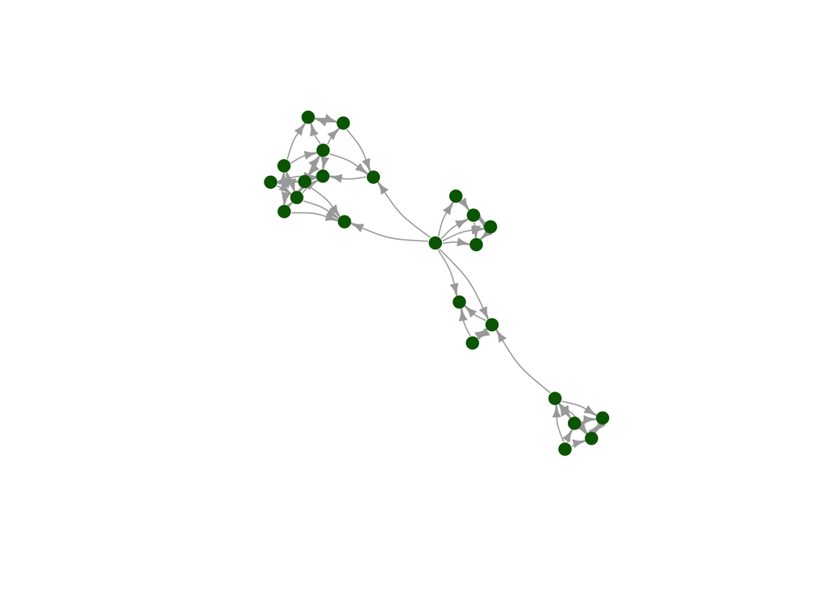

```r
plot(teachergraph, vertex.size=8, vertex.label=NA, vertex.color="darkgreen", vertex.frame.color="NA", edge.arrow.size=0.5,  edge.curved=0.2)
```

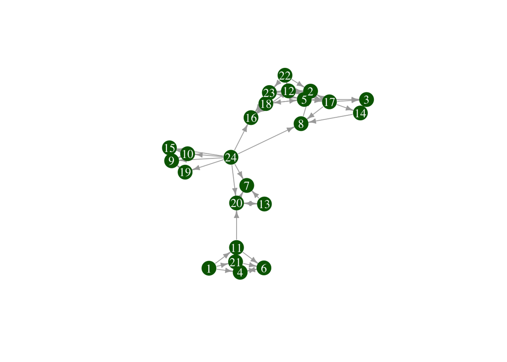

```r
## What is I wanted to save the node positions?
coords=layout_with_fr(teachergraph) ## this is the most common layout
plot(teachergraph, vertex.size=15, vertex.frame.color=NA,  vertex.color="darkgreen", vertex.label.color="white", edge.arrow.size=0.5, layout=coords)
```

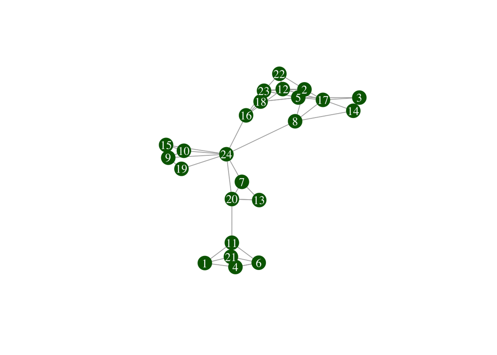

```r
## To remove arrows
plot(teachergraph, vertex.size=15, vertex.frame.color=NA, vertex.label=1:24, vertex.color="darkgreen", vertex.label.color="white", vertex.label=1:24, edge.arrow.size=0.5, layout=coords, edge.arrow.mode=0)
```

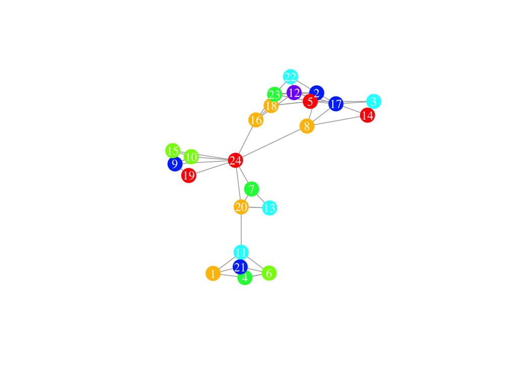

```r
## To color the nodes based on grade taught
mycolors=rainbow(8)
plot(teachergraph, vertex.size=15, vertex.frame.color=NA, vertex.label=1:24, vertex.color=mycolors[Teacher9$grade], vertex.label.color="white", vertex.label=1:24, edge.arrow.size=0.5, layout=coords, edge.arrow.mode=0)
```

```r
## We can then save these plots as pdfs!
```

## Redoing the CoAuthorship Network with some changes

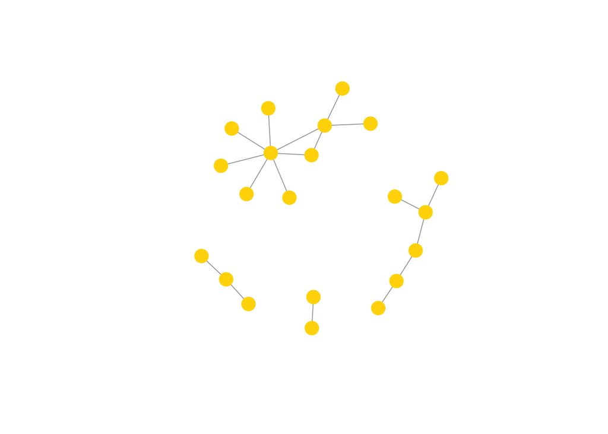

```r
plot(authorgraph, vertex.size=12, vertex.frame.color=NA, vertex.color="gold", vertex.label=NA, edge.arrow.mode=0)
```

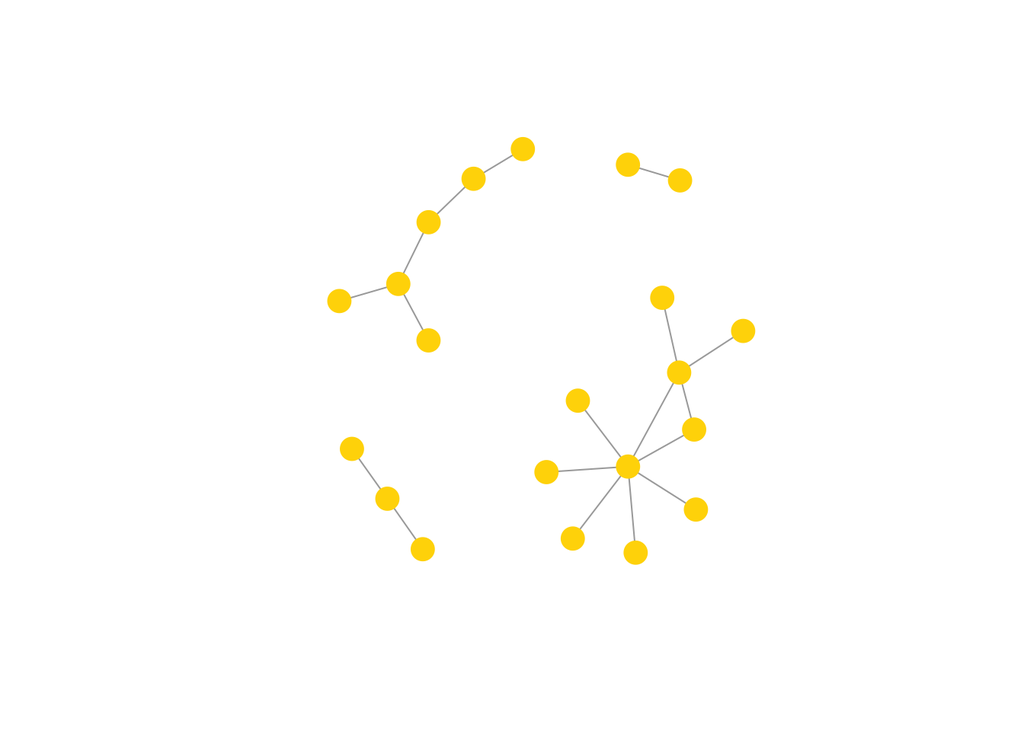

```r
coords=layout_nicely(authorgraph)
plot(authorgraph, vertex.size=12, vertex.frame.color=NA, vertex.color="gold", vertex.label=NA, edge.arrow.mode=0, layout=coords)
```

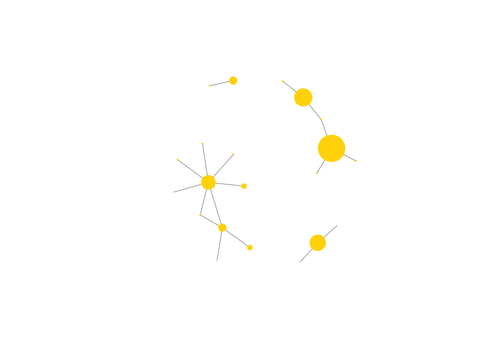

```r
## Sometimes it doesn't always work and just rerunning the code will get you a nicer looking plot.

## Leaders are bigger
plot(authorgraph, vertex.size=authordf$YrsPostPhD, vertex.frame.color=NA,
    vertex.color="gold", vertex.label=NA, edge.arrow.mode=0)
```

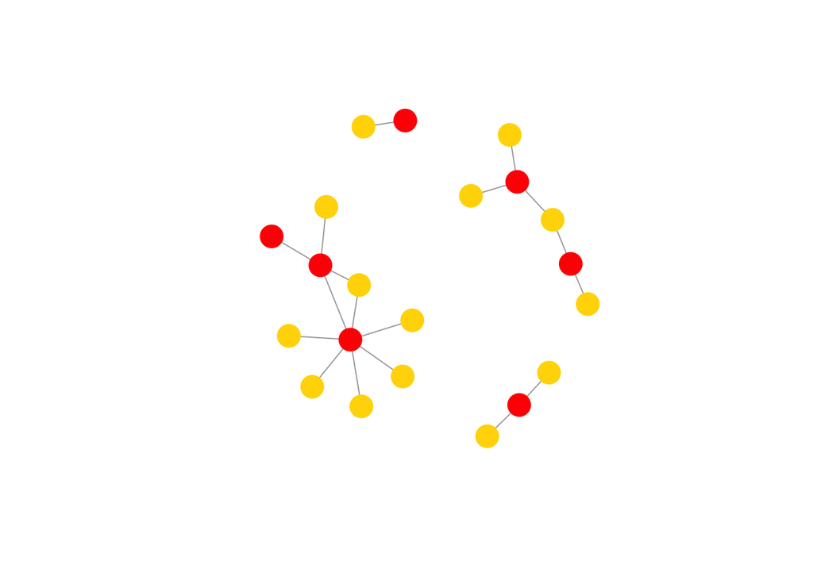

```r
## Faculty are colored differently
mycolors=c("gold", "red")
faculty=authordf$CurrentFaculty+1
plot(authorgraph, vertex.size=15, vertex.frame.color=NA,
    vertex.color=mycolors[faculty], vertex.label=NA, edge.arrow.mode=0)
```

## Descriptive Statistics

### Describing the Network

Density, reciprocity and transitivity

```r
teachergraph=graph.adjacency(Ela9Network)
edge_density(teachergraph)
```

```
## [1] 0.1032609
```

```r
edge_density(authorgraph)
```

```
## [1] 0.08571429
```

```r
reciprocity(teachergraph)
```

```
## [1] 0.3508772
```

```r
## Remember this transitivity
## function forces all ties to bidirectional!
transitivity(teachergraph)
```

```
## [1] 0.490566
```

```r
transitivity(authorgraph)
```

```
## [1] 0.08823529
```

### Describing the Nodes

To calculate degree, use the argument “mode” to determine whether you want to calculate in-degree, out-degree or degree (sum of in and out). Recall that in and out degree are for directed networks only.What you get is the in-, out-, or total degree for each node. Note that if you don’t select a mode, you get the sum by default.

```r
degree(teachergraph, mode="in")
```

```
##  1  2  3  4  5  6  7  8  9 10 11 12 13 14 15 16 17 18 19 20 21 22 23 24
##  0  5  3  4  2  3  3  3  3  2  2  3  1  2  3  4  2  1  1  3  2  1  4  0
```

```r
degree(teachergraph, mode="out")
```

```
##  1  2  3  4  5  6  7  8  9 10 11 12 13 14 15 16 17 18 19 20 21 22 23 24
##  3  0  1  1  4  1  0  1  2  2  4  5  2  2  0  0  5  3  1  2  3  3  4  8
```

```r
degree(authorgraph)
```

```
##  V1  V2  V3  V4  V5  V6  V7  V8  V9 V10 V11 V12 V13 V14 V15 V16 V17 V18 V19 V20
##   3   7   2   2   4   1   1   2   1   2   1   1   1   1   1   1   1   1   1   1
## V21
##   1
```

Closeness and betweenness are also directional since it’s based on the distance between pairs of nodes.

```r
## Recall that closeness and betweenness don't work well for disconnected graphs
closeness(teachergraph, mode="out")
```

```
##          1          2          3          4          5          6          7
## 0.07692308        NaN 0.16666667 1.00000000 0.05882353 1.00000000        NaN
##          8          9         10         11         12         13         14
## 1.00000000 0.50000000 0.50000000 0.12500000 0.06250000 0.50000000 0.25000000
##         15         16         17         18         19         20         21
##        NaN        NaN 0.05555556 0.05000000 0.20000000 0.50000000 0.09090909
##         22         23         24
## 0.04761905 0.05555556 0.08333333
```

```r
betweenness(teachergraph, directed=TRUE)
```

```
##          1          2          3          4          5          6          7
##  0.0000000  0.0000000  1.3333333  0.3333333 11.1666667  0.0000000  0.0000000
##          8          9         10         11         12         13         14
##  3.0000000  2.0000000  0.0000000  6.3333333 13.3333333  0.0000000  2.0000000
##         15         16         17         18         19         20         21
##  0.0000000  0.0000000 11.6666667  0.5000000  0.0000000  7.0000000  0.3333333
##         22         23         24
##  0.0000000 12.0000000  0.0000000
```

```r
betweenness(authorgraph, directed=FALSE)
```

```
##  V1  V2  V3  V4  V5  V6  V7  V8  V9 V10 V11 V12 V13 V14 V15 V16 V17 V18 V19 V20
##   7  30   4   1  15   0   0   6   0   0   0   0   0   0   0   0   0   0   0   0
## V21
##   0
```

### Edge Statistics

There are a number of distance functions in igraph. See http://igraph.org/r/doc/distances.html for more information. To calculate the geodesic distance (shortest path) between every pair of nodes.

```r
## We typically use out for geodesic distance for directed networks
distances(teachergraph, mode="out")
```

```
##      1   2   3   4   5   6   7   8   9  10  11  12  13  14  15  16  17  18  19
## 1    0 Inf Inf   1 Inf   2   3 Inf Inf Inf   1 Inf   3 Inf Inf Inf Inf Inf Inf
## 2  Inf   0 Inf Inf Inf Inf Inf Inf Inf Inf Inf Inf Inf Inf Inf Inf Inf Inf Inf
## 3  Inf   3   0 Inf Inf Inf Inf   2 Inf Inf Inf Inf Inf   1 Inf Inf Inf Inf Inf
## 4  Inf Inf Inf   0 Inf   1 Inf Inf Inf Inf Inf Inf Inf Inf Inf Inf Inf Inf Inf
## 5  Inf   2   1 Inf   0 Inf Inf   2 Inf Inf Inf   2 Inf   2 Inf   2   1   1 Inf
## 6  Inf Inf Inf   1 Inf   0 Inf Inf Inf Inf Inf Inf Inf Inf Inf Inf Inf Inf Inf
## 7  Inf Inf Inf Inf Inf Inf   0 Inf Inf Inf Inf Inf Inf Inf Inf Inf Inf Inf Inf
## 8  Inf   1 Inf Inf Inf Inf Inf   0 Inf Inf Inf Inf Inf Inf Inf Inf Inf Inf Inf
## 9  Inf Inf Inf Inf Inf Inf Inf Inf   0   1 Inf Inf Inf Inf   1 Inf Inf Inf Inf
## 10 Inf Inf Inf Inf Inf Inf Inf Inf   1   0 Inf Inf Inf Inf   1 Inf Inf Inf Inf
## 11 Inf Inf Inf   1 Inf   1   2 Inf Inf Inf   0 Inf   2 Inf Inf Inf Inf Inf Inf
## 12 Inf   1   2 Inf   2 Inf Inf   2 Inf Inf Inf   0 Inf   2 Inf   1   1   3 Inf
## 13 Inf Inf Inf Inf Inf Inf   1 Inf Inf Inf Inf Inf   0 Inf Inf Inf Inf Inf Inf
## 14 Inf   2   1 Inf Inf Inf Inf   1 Inf Inf Inf Inf Inf   0 Inf Inf Inf Inf Inf
```

[output cut: 35 more lines]

```r
## Note you can choose "in" or "all"
## the default option is "all" which is
## appropriate for undirected networks
```

## Community Detection

```r
library(igraph)
teachergraph=graph.adjacency(Ela9Network)
```

### Random Walk Community Detection

```r
wtc=cluster_walktrap(teachergraph, steps=4)

## membership returns a membership id for each node
wtc.membership=membership(wtc)
wtc.membership
```

```
##  1  2  3  4  5  6  7  8  9 10 11 12 13 14 15 16 17 18 19 20 21 22 23 24
##  5  2  3  5  2  5  4  3  1  1  5  2  4  3  1  2  3  2  1  4  5  2  2  1
```

```r
## communities returns a list of node names in each block
communities(wtc)
```

```
## $`1`
## [1] "9"  "10" "15" "19" "24"
##
## $`2`
## [1] "2"  "5"  "12" "16" "18" "22" "23"
##
## $`3`
## [1] "3"  "8"  "14" "17"
##
## $`4`
## [1] "7"  "13" "20"
##
## $`5`
## [1] "1"  "4"  "6"  "11" "21"
```

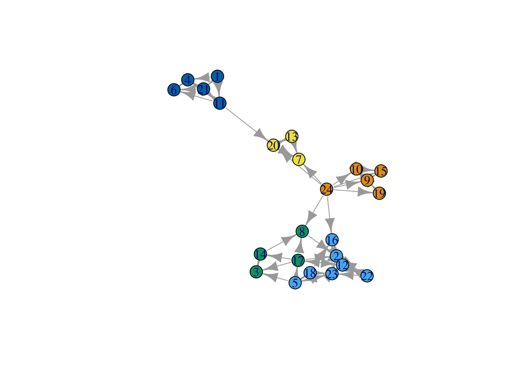

```r
plot(teachergraph, vertex.color=wtc.membership, vertex.size=12)
```

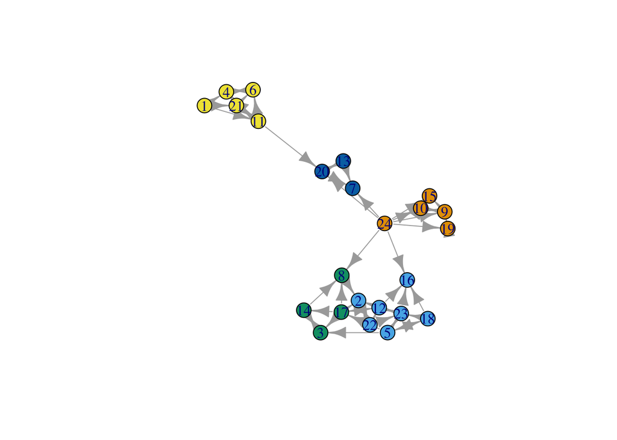

```r
## Let's try this again with a larger number of steps
wtc=cluster_walktrap(teachergraph, steps=6)
wtc.membership2=membership(wtc)
plot(teachergraph, vertex.color=wtc.membership2, vertex.size=12)
```

### Edge Betweenness

```r
ebc=cluster_edge_betweenness(teachergraph)
## Notice that the membership for the highest modularity is returned ##
membership(ebc)
```

```
##  1  2  3  4  5  6  7  8  9 10 11 12 13 14 15 16 17 18 19 20 21 22 23 24
##  1  2  3  4  5  4  6  6  6  6  4  2  7  8  6  6  9  2  6  6  4  2  2  6
```

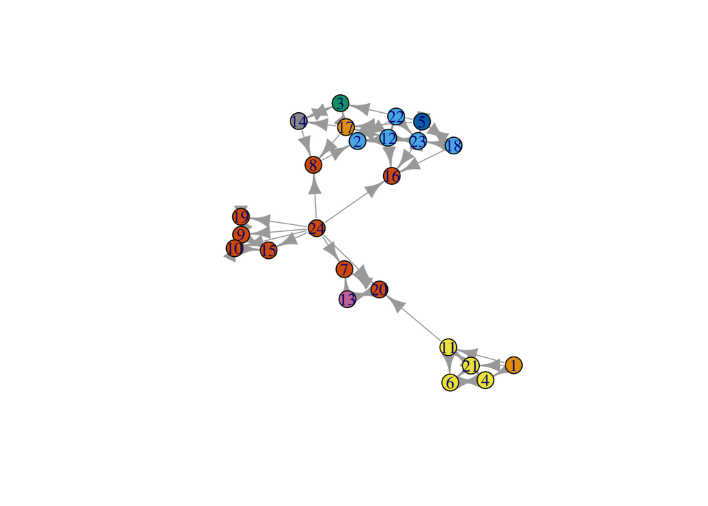

```r
ebc.membership=membership(ebc)
plot(teachergraph, vertex.color=ebc.membership, vertex.size=12)
```

### Fast Greedy

We’ll need to change the network slightly so we can work with this algorithm. Let’s change the network.

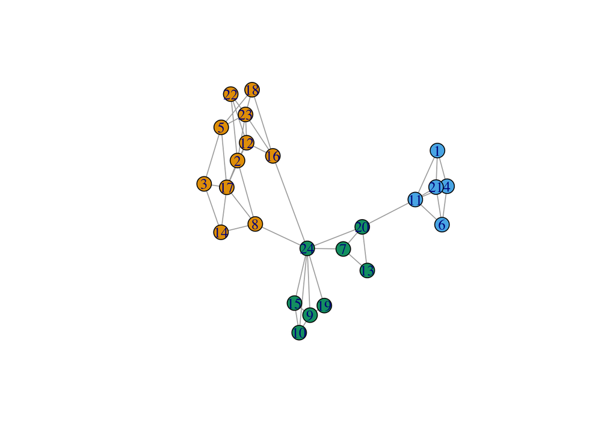

```r
teachergraph2=graph.adjacency(Ela9Network, mode="undirected")
fgc=cluster_fast_greedy(teachergraph2)
fgc.membership=membership(fgc)
plot(teachergraph2, vertex.color=fgc.membership, vertex.size=12)
```